# movecost 3.x: a task-based guide

Gianmarco Alberti

## Introduction

This vignette shows the use of the `movecost` package through a sequence of practical tasks, in the same question-and-answer spirit as the guide that accompanied the 2.x series. In-built datasets are used throughout, so that you can reproduce every example. For full details of each function, its parameters, returned values, and references, see the package help documentation (start at `?movecost`).

If you are coming from the 2.x series, two changes shape everything below.

**1. Compute the cost surface once, then reuse it.** In 2.x each function (`movecost()`, `movecorr()`, and so on) rebuilt the movement-cost surface from scratch every time it was called. In 3.0 you build that surface once with `mc_surface()`, and every analysis function takes it as its first argument and reuses it. Parameters that define the cost of movement (the cost function `funct`, the connectivity `move`, the terrain factor `N` or a terrain raster, the body/load/speed parameters `W`, `L`, `V`, the critical slope `sl.crit`, the cognitive-slope and topographic-distance switches, and any `barrier`) belong to `mc_surface()`. Parameters that only affect accumulation, units, or display (the origin, the time unit, the isoline interval) belong to the analysis and plot functions. If you change a cost-defining parameter you rebuild the surface; if you only change the unit or the breaks you do not.

**2. Visualise on demand.** Every analysis function returns an object that *stores* its result; nothing is drawn until you call `plot()` on it. The plot is a `ggplot` object, so you can restyle it, add layers, and redraw it without re-running the analysis (in 2.x, a new look meant a new computation).

```r
library(movecost)

dtm    <- mc_volc()        # sample DTM (a volcano), a terra SpatRaster
origin <- mc_volc_loc()    # a start location, an sf point
destin <- mc_destin_loc()  # nine destination locations, sf points
```

## Task 1. Given an origin, how do I calculate an accumulated cost surface?

Build the surface once with `mc_surface()`, then accumulate cost outward from the origin with `mc_accum()`. Here the cost is walking time (Tobler’s on-path hiking function, `funct = "t"`), the time unit is minutes, and the isochrone interval is 2 minutes.

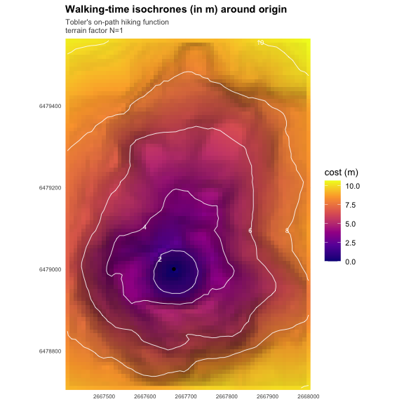

```r
surf <- mc_surface(dtm, funct = "t", move = 16)
acc  <- mc_accum(surf, origin = origin, time = "m", breaks = 2)
plot(acc)
```

The isolines are white by default so that they read against the dark low-cost core; `plot(acc, type = "contour")` draws the isolines alone.

## Task 2. Can I use a terrain factor for a given terrain type?

Yes. The terrain factor `N` defines the cost of movement, so it is set on `mc_surface()`; everything else is unchanged. Here `N = 1.19` corresponds to loose beach sand.

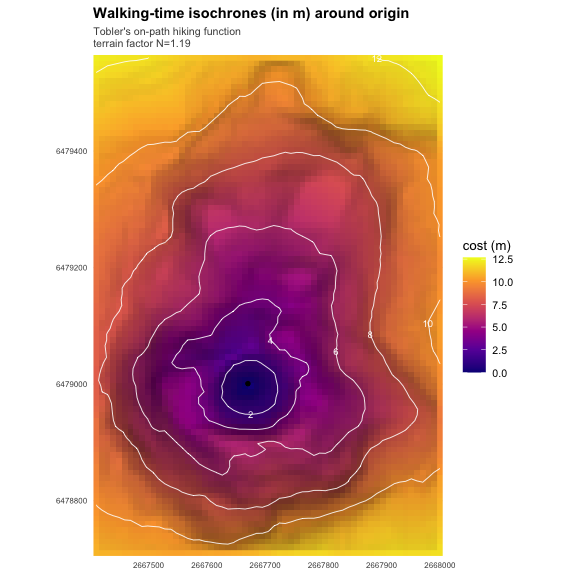

```r
surf_N <- mc_surface(dtm, funct = "t", move = 16, N = 1.19)
acc_N  <- mc_accum(surf_N, origin = origin, time = "m", breaks = 2)
plot(acc_N)
```

The off-path functions (`tofp`, `icmoffp`, `icfoffp`) do not take a terrain factor, since they already embed off-path walking. If `N` (other than the default 1) or a terrain raster (Task 3) is passed to one of them, it is ignored: the surface is built from the off-path function as it is, and a warning names the corresponding on-path function (`t`, `icmonp`, `icfonp`), which does take the terrain factor. Alberti’s function (`alb`), which models the walking pace of a flock, does not take a terrain factor either.

## Task 3. Can the terrain factor vary across the study area?

Yes (from version 3.1.0). Instead of a single `N`, pass a raster to `mc_surface()` through `terrain`. The raster can hold terrain factors directly, or terrain classes (land-cover types, say) that a lookup table, `terrain.table`, translates into terrain factors. `mc_terrain_factors()` returns the documented reference values from which such a table can be built.

Here a fictitious land-cover raster is derived from slope: gentle ground is lawn grass, moderate slopes are tall grassland, steep slopes are rock.

```r
slp  <- terra::terrain(dtm, v = "slope")      # slope in degrees
land <- terra::classify(slp, rbind(c(-Inf, 10, 1), c(10, 20, 2), c(20, Inf, 3)))
levels(land) <- data.frame(id = 1:3, cover = c("grass", "tall grass", "rock"))

tf  <- mc_terrain_factors("time")
tab <- data.frame(class = c("grass", "tall grass", "rock"),
                  N = tf$N[match(c("Lawn grass",
                                   "Tall grassland (with thistle and nettles)",
                                   "Rock"), tf$terrain)])
tab
```

```
#>        class    N
#> 1      grass 1.03
#> 2 tall grass 1.35
#> 3       rock 2.50
```

```r
surf_T <- mc_surface(dtm, funct = "t", move = 16,
                     terrain = land, terrain.table = tab)
```

```
#> Note: 292 DTM cell(s) with no terrain value take the scalar N = 1.
```

```r
surf_T
```

```
#> movecost cost surface
#>   cost function : Tobler's hiking function (on-path) ('t')
#>   cost unit     : hours (or minutes)
#>   DTM           : 87 x 61 cells, resolution 9.84 x 9.89
#>   connectivity  : 16 directions; 82,268 graph edges
#>   terrain factor: raster, N from 1 to 2.5; 292 cell(s) with scalar N = 1
#> Reuse this object with mc_accum(), mc_paths(), mc_corridor(), mc_boundary(),
#> mc_alloc(), mc_network(), mc_rank(); plot() it for a quick look.
```

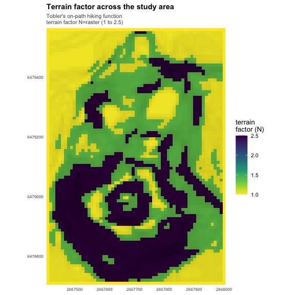

```r
plot(surf_T, type = "terrain")
```

The slope raster has no value along the DTM’s outer edge, so those cells have no terrain class; they take the scalar `N` (1 by default), as the message reports. The terrain plot shows the factors actually used, so this step can be checked visually. Everything downstream is unchanged:

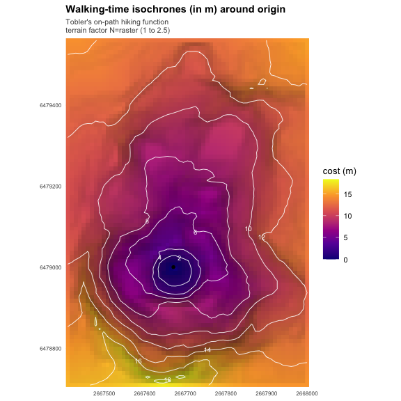

```r
acc_T <- mc_accum(surf_T, origin = origin, time = "m", breaks = 2)
plot(acc_T)
```

Since unmapped cells fall back on `N`, only the terrain types of interest need mapping. Below, a single track is mapped (terrain factor 1, the value for improved paths) and the rest of the area is treated as off-path (`N = 1.67`):

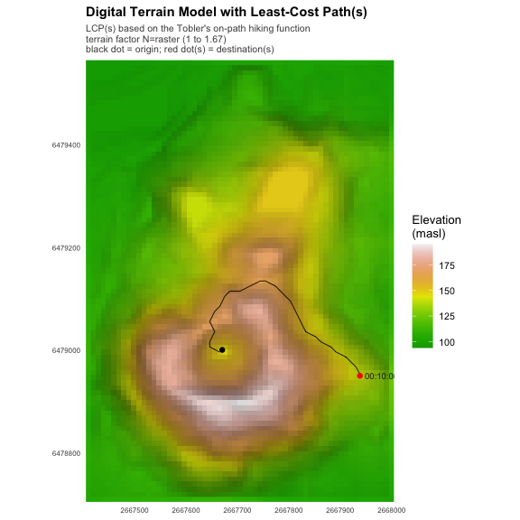

```r
track <- mc_paths(surf, origin = origin, destin = destin[2, ])$paths
track_r <- terra::rasterize(terra::vect(track), dtm, field = 1, touches = TRUE)
surf_track <- suppressMessages(
  mc_surface(dtm, funct = "t", move = 16, terrain = track_r, N = 1.67))
plot(mc_paths(surf_track, origin = origin, destin = destin[3, ]))
```

A few points are worth knowing (see `?mc_surface` for details). Each edge between two cells takes the mean of their terrain factors. A raster that does not match the DTM’s grid or coordinate system is aligned to it with nearest-neighbour resampling, with a warning. A few functions do not take a terrain factor and ignore the raster, with a warning: the off-path functions, which already embed off-path walking (use their on-path versions, which do take the raster), and Alberti’s, which models the walking pace of a flock. Finally, published terrain factors are convenient documented values, not calibrated constants.

## Task 4. Can cost be expressed as metabolic energy rather than time?

Yes. Many energetic cost functions are implemented. This example uses the Pandolf et al. function with downhill correction (`funct = "pcf"`), a body weight `W` of 60 kg and a carried load `L` of 5 kg. The walking speed `V` defaults to 1.2 m/s and is treated as uniform across the area. The function gives a metabolic rate, which movecost divides by the walking speed, so the accumulated value is the energy spent, in kJ (see `mc_cost_functions()` for the unit of each function).

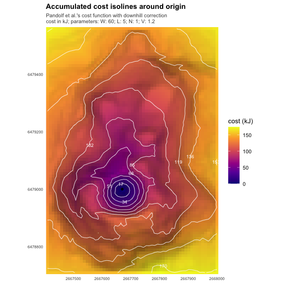

```r
surf_e <- mc_surface(dtm, funct = "pcf", move = 16, W = 60, L = 5)
acc_e  <- mc_accum(surf_e, origin = origin)
plot(acc_e)
```

## Task 5. Can the walking speed be worked out internally?

Yes. Setting `V = 0` makes the function derive the walking speed cell by cell from the Tobler hiking function, so the speed varies with the terrain slope instead of being a single value.

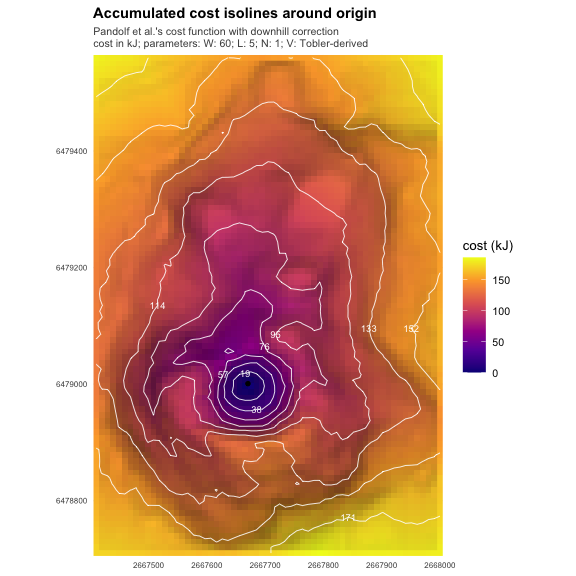

```r
surf_v <- mc_surface(dtm, funct = "pcf", move = 16, W = 60, L = 5, V = 0)
acc_v  <- mc_accum(surf_v, origin = origin)
plot(acc_v)
```

## Task 6. Can the ‘cognitive slope’ be used?

Yes. Setting `cogn.slp = TRUE` on `mc_surface()` multiplies positive slopes by 1.99 and negative slopes by 2.31 before the cost function is applied, following Pingel (2013).

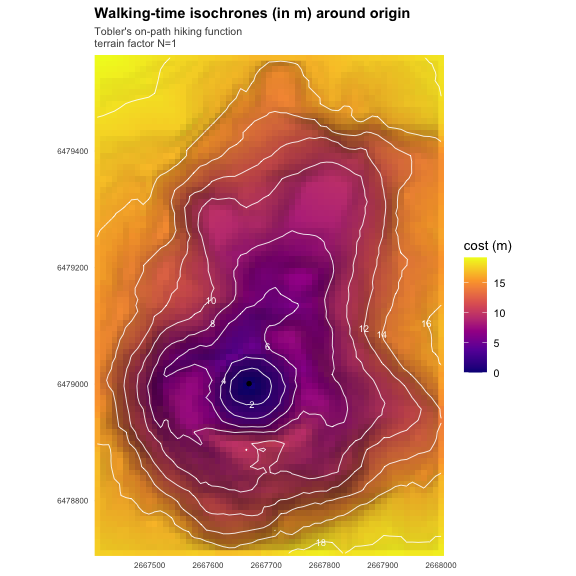

```r
surf_c <- mc_surface(dtm, funct = "t", move = 16, cogn.slp = TRUE)
acc_c  <- mc_accum(surf_c, origin = origin, time = "m", breaks = 2)
plot(acc_c)
```

## Task 7. Can least-cost paths to one or more destinations be calculated?

Yes, with `mc_paths()`, which reuses the same surface from Task 1. Each path carries its accumulated `cost` and `length`; for time-based functions the destinations are labelled in sexagesimal format (hh:mm:ss).

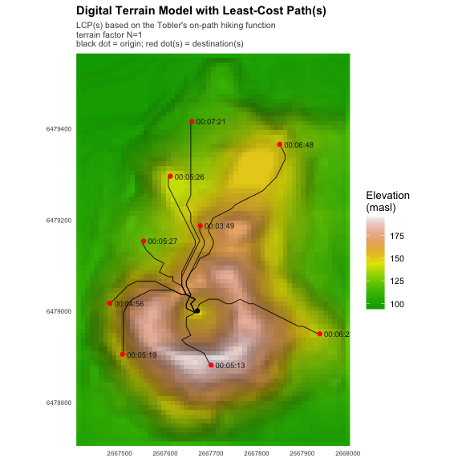

```r
lcp <- mc_paths(surf, origin = origin, destin = destin, time = "m")
plot(lcp)
```

Note the 3.0 idiom: the accumulated surface (Task 1) and the least-cost paths are two separate result objects from the *same* surface, each plotted when you want it. There is no `oneplot` parameter because you simply call `plot()` on whichever object you wish.

## Task 8. Can the paths back to the origin be calculated?

Yes. Because the cost is anisotropic, the return route can differ from the outward one. Set `return.base = TRUE`; the return paths are drawn dashed.

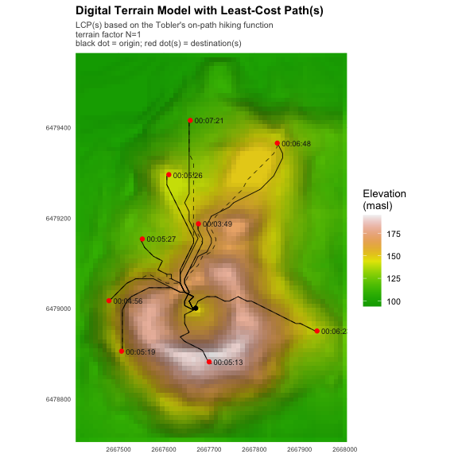

```r
lcp_b <- mc_paths(surf, origin = origin, destin = destin, time = "m",
                  return.base = TRUE)
plot(lcp_b)
```

## Task 9. Can a least-cost corridor be calculated?

Yes, with `mc_corridor()`. By default (`method = "reach"`) the corridor is the classic one of the 2.x series and the GIS literature (Mitchell 2012): the sum of the accumulated cost spreading outward from each location, so the value of a cell is the total cost to reach it from both. The two least-cost paths (A to B and B to A) are overlaid. Here the wheeled-vehicle cost function is used; its critical slope is set on the surface via `sl.crit` (default 10 percent).

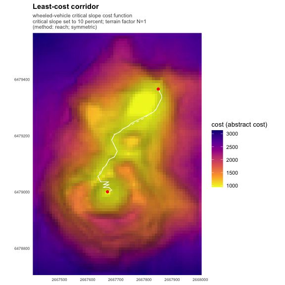

```r
surf_wcs <- mc_surface(dtm, funct = "wcs", move = 16, sl.crit = 10)
corr <- mc_corridor(surf_wcs, a = origin, b = destin[2, ])
plot(corr)
```

A new `method = "through"` option computes instead a directional A-to-B band, `cost(A->x) + cost(x->B)`, whose minimum equals the A-to-B least-cost-path cost; it is intended for one-way journey analysis. See `?mc_corridor` for when to prefer each.

## Task 10. Can I compare paths from different cost functions?

Yes, with `mc_comp()`. Because each cost function defines its own surface, `mc_comp()` takes the DTM (not a pre-built surface) and builds one surface per function internally. Here four time-based functions are compared. All nine destinations are used, so that the comparison chart below has a distribution to summarise.

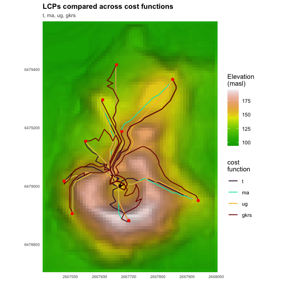

```r
cmp <- mc_comp(dtm, origin = origin, destin = destin,
               functs = c("t", "ma", "ug", "gkrs"), move = 16)
plot(cmp)
```

Setting `type = "chart"` reproduces the `add.chart` output of the 2.x `movecomp()`: two boxplots showing, for each cost function, the distribution across the destinations of the path length and of the cost. As in the 2.x guide, one can see, for instance, whether a given function (here `gkrs`) tends to produce longer paths than the others.

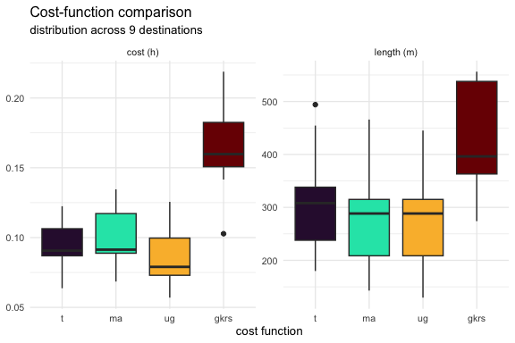

```r
plot(cmp, type = "chart")
```

A terrain raster (Task 3) can be passed to `mc_comp()` too, along with `terrain.table`; it is aligned to the DTM once and shared by all the compared functions. The functions that do not take a terrain factor ignore it, with a warning: an off-path function would then show paths unaffected by the mapped terrain next to the others, so compare its on-path version instead; Alberti’s, which models a flock’s pace, is not meant to take a terrain factor at all.

```r
# the cells without a terrain class were reported in Task 3
cmp_T <- suppressMessages(
  mc_comp(dtm, origin = origin, destin = destin[2, ], functs = c("t", "ks"),
          move = 16, terrain = land, terrain.table = tab))
cmp_T$cost.table
```

```
#>   funct destination      cost cost_unit       length
#> 1     t           1 0.1709587         h 462.8256 [m]
#> 2    ks           1 0.1601539         h 449.7628 [m]
```

## Task 11. What if I do not have an elevation raster?

Use `mc_dtm()` to download elevation data for a study-area polygon (this needs the optional `elevatr` package). The resolution is set by the zoom level `z` (default 9). The code below is not executed here because it requires an internet connection.

```r
boundary <- mc_etna_boundary()                 # sample study-area polygon
dtm_etna <- mc_dtm(boundary, z = 9)            # download elevation data
cmp_etna <- mc_comp(dtm_etna,
                    origin = mc_etna_start(),
                    destin = mc_etna_end(),
                    functs = c("t", "wcs"), move = 16)
plot(cmp_etna)
```

## Task 12. Can I calculate a walking-cost boundary, e.g. a 45-minute catchment?

Yes, with `mc_boundary()`. The `limit` is the cost value defining the boundary. In 3.0 the boundary is obtained by polygonising the reachable area directly, so the returned polygons are closed and carry their `area` and `perimeter` (no extra parameter is needed for this). The example uses the larger Malta DTM, which gives a more informative result than the small volcano, to draw 30-minute walking boundaries (Tobler off-path function) around three springs.

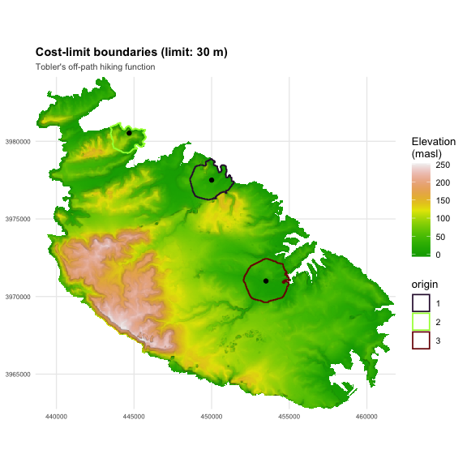

```r
malta_b <- mc_malta_dtm()
springs_b <- mc_springs()
surf_b <- mc_surface(malta_b, funct = "tofp", move = 8)
bnd <- mc_boundary(surf_b, origin = springs_b[c(5, 15, 30), ],
                   limit = 30, time = "m")
plot(bnd)
```

```r
bnd
```

```
#> movecost cost-limit boundaries
#>   cost function : tofp
#>   cost limit    : 30 (m)
#>   origins       : 3
#>   origin_id limit          area perimeter
#> 1         1    30 4745600 [m^2] 13280 [m]
#> 2         2    30 2926400 [m^2] 10880 [m]
#> 3         3    30 6016000 [m^2] 13040 [m]
#> Use plot() to visualise; mc_export() to write to disk.
```

## Task 13. Can I carry out a cost-allocation analysis?

Yes, with `mc_alloc()`. Each cell is assigned to the origin it can be reached from at the smallest cost. Here three origins are used and the Ardigo et al. metabolic function.

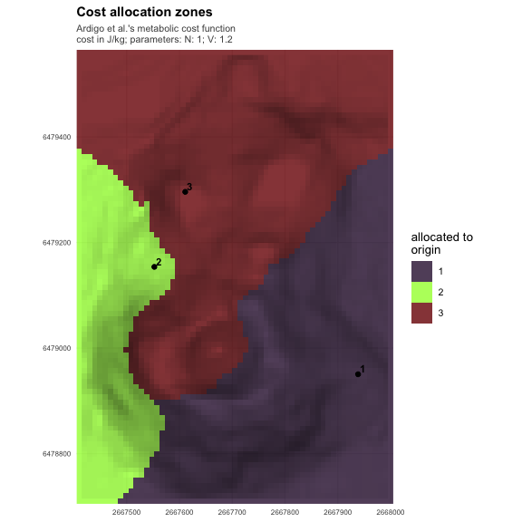

```r
surf_a <- mc_surface(dtm, funct = "a", move = 16)
al <- mc_alloc(surf_a, origin = destin[c(3, 7, 9), ])
plot(al)
```

Each origin and its zone share the same index (the labels are drawn by default).

## Task 14. Can I show isolines inside each allocation zone?

Yes. The allocation result already stores the isolines of the minimum-cost surface; set `isolines = TRUE` in the plot call to overlay them.

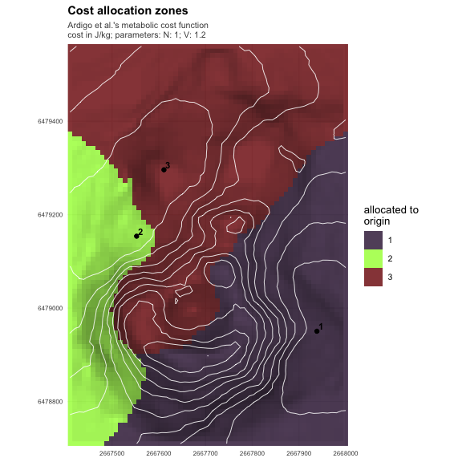

```r
plot(al, isolines = TRUE)
```

## Task 15. Can I calculate a network of least-cost paths?

Yes, with `mc_network()`. Two network types are available: `"allpairs"` connects every location to every other; `"neigh"` connects each location to its cost-wise nearest neighbour. The nodes are numbered to match the returned cost matrix.

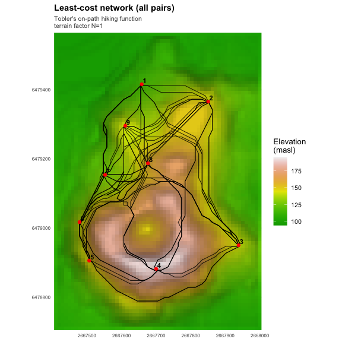

```r
surf_t <- mc_surface(dtm, funct = "t", move = 16)
nw_all <- mc_network(surf_t, nodes = destin, type = "allpairs")
plot(nw_all)
```

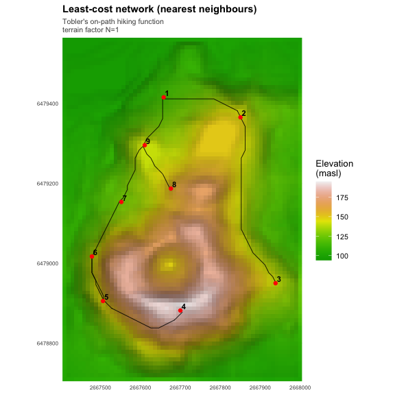

```r
nw_nei <- mc_network(surf_t, nodes = destin, type = "neigh")
plot(nw_nei)
```

The full origin-to-origin cost matrix is returned; note that it is **not** symmetric, because the cost is anisotropic (A to B need not equal B to A):

```r
round(nw_nei$cost.matrix, 2)
```

```
#>      1    2    3    4    5    6    7    8    9
#> 1 0.00 0.07 0.15 0.19 0.15 0.11 0.07 0.09 0.05
#> 2 0.05 0.00 0.09 0.15 0.14 0.11 0.08 0.06 0.06
#> 3 0.14 0.09 0.00 0.10 0.12 0.14 0.14 0.10 0.12
#> 4 0.14 0.11 0.07 0.00 0.06 0.08 0.11 0.08 0.11
#> 5 0.11 0.13 0.12 0.09 0.00 0.02 0.06 0.08 0.09
#> 6 0.09 0.12 0.14 0.11 0.03 0.00 0.03 0.07 0.07
#> 7 0.06 0.10 0.14 0.15 0.07 0.04 0.00 0.06 0.04
#> 8 0.06 0.05 0.08 0.11 0.08 0.06 0.04 0.00 0.03
#> 9 0.04 0.06 0.12 0.15 0.10 0.07 0.03 0.04 0.00
```

## Task 16. Can I calculate the density of a network of paths?

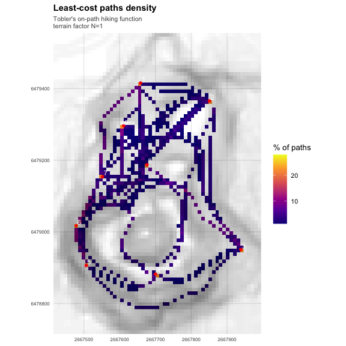

```r
nw_d <- mc_network(surf_t, nodes = destin, type = "allpairs", density = TRUE)
plot(nw_d, type = "density")
```

## Task 17. My DTM has NoData (sea); how do I stop paths crossing it?

In 3.0 you do nothing: NoData cells are excluded from the cost graph by construction, so accumulated costs and paths can never cross them. The `irregular.dtm` parameter of 2.x is no longer needed. Here the Malta DTM has sea cells set to NoData, and the path follows the coastline automatically.

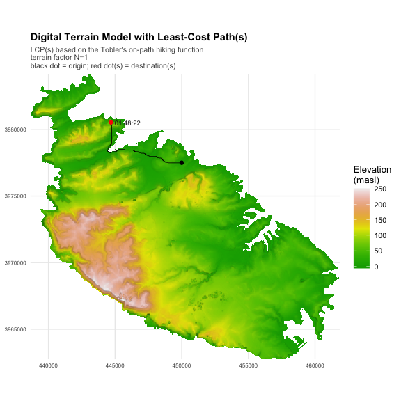

```r
malta <- mc_malta_dtm()
springs <- mc_springs()
surf_malta <- mc_surface(malta, funct = "t", move = 8)
lcp_coast  <- mc_paths(surf_malta, origin = springs[5, ], destin = springs[15, ])
plot(lcp_coast)
```

## Task 18. Can I include a barrier (an area where movement is inhibited)?

Yes. A barrier (lines or polygons) is supplied to `mc_surface()`, since it changes the cost graph. Edges touching the barrier are given conductance 0 by default (impassable); set `field` to a small value to penalise rather than forbid. Here a path computed first is reused as a barrier.

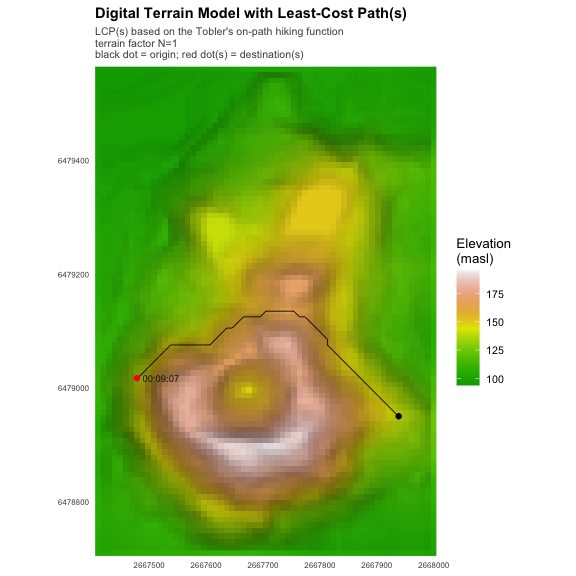

```r
# a path to reuse as a barrier
surf8 <- mc_surface(dtm, funct = "t", move = 8)
bar   <- mc_paths(surf8, origin = destin[1, ], destin = destin[4, ])$paths

# without the barrier
free <- mc_paths(surf8, origin = destin[3, ], destin = destin[6, ])
plot(free)
```

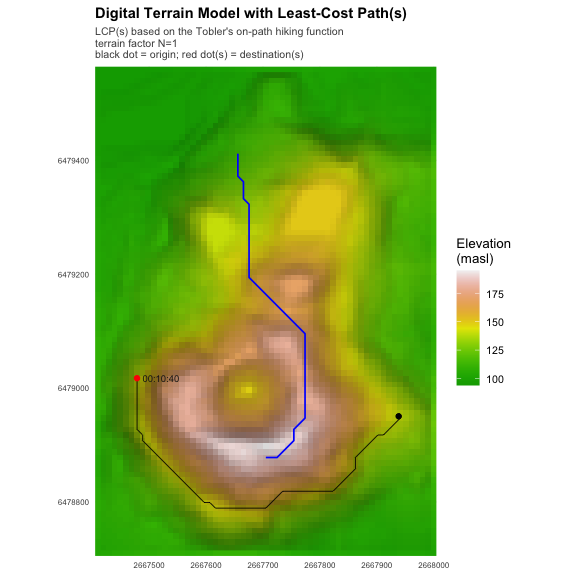

```r
# with the barrier (built into a new surface)
surf_bar <- mc_surface(dtm, funct = "t", move = 8, barrier = bar)
blocked  <- mc_paths(surf_bar, origin = destin[3, ], destin = destin[6, ])
plot(blocked, plot.barrier = TRUE)
```

The path in the second plot makes a detour to avoid the barrier (drawn in blue). With `move = 16`, knight-move steps could jump a thin barrier; use `move = 8` if that must not happen.

## Task 19. Can I calculate sub-optimal (ranked) least-cost paths?

Yes, with `mc_rank()`. It returns the optimal path (rank 1) and progressively sub-optimal alternatives, found by penalising the edges of earlier paths and re-running the search. Unlike 2.x (capped at six), any number `k` of ranks can be requested, and the avoidance strength is the `penalty` argument.

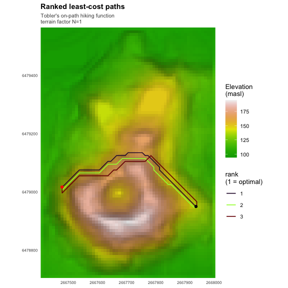

```r
rk <- mc_rank(surf8, origin = destin[3, ], destin = destin[6, ], k = 3)
plot(rk)
```

```r
rk$paths                                   # rank, cost, length
```

```
#> Simple feature collection with 3 features and 4 fields
#> Geometry type: LINESTRING
#> Dimension:     XY
#> Bounding box:  xmin: 2667479 ymin: 6478947 xmax: 2667941 ymax: 6479135
#> Projected CRS: NZGD49 / New Zealand Map Grid
#>   rank      cost                       geometry cost_hms       length
#> 1    1 0.1519549 LINESTRING (2667941 6478947... 00:09:07 595.4477 [m]
#> 2    2 0.1635586 LINESTRING (2667941 6478947... 00:09:49 606.9999 [m]
#> 3    3 0.1748028 LINESTRING (2667941 6478947... 00:10:29 620.9939 [m]
```

## Task 20. Can the ranked paths be drawn over a least-cost corridor?

Yes, directly: `plot(rk, type = "corridor")` draws the ranked paths over the least-cost corridor between the two locations, which `mc_rank()` has already computed and stored. This is the equivalent of 2.x’s `use.corr`, with no manual steps.

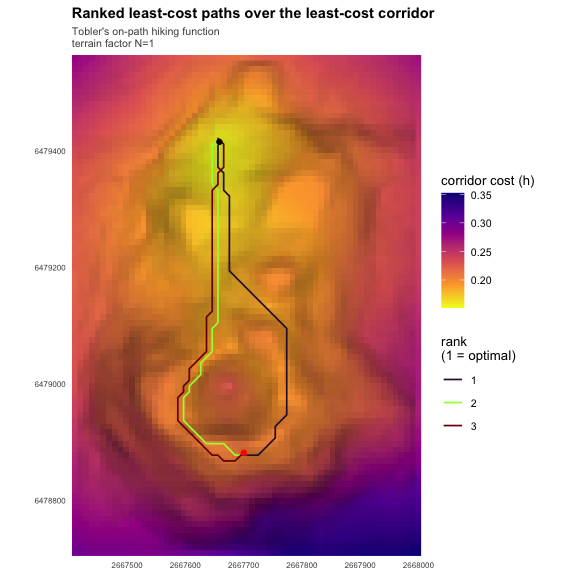

```r
rk2 <- mc_rank(surf8, origin = destin[1, ], destin = destin[4, ], k = 3)
plot(rk2, type = "corridor")
```

## Task 21. Can barriers be used with ranked paths?

Yes: build the surface with the barrier, then run `mc_rank()` on it. The ranked paths all avoid the barrier.

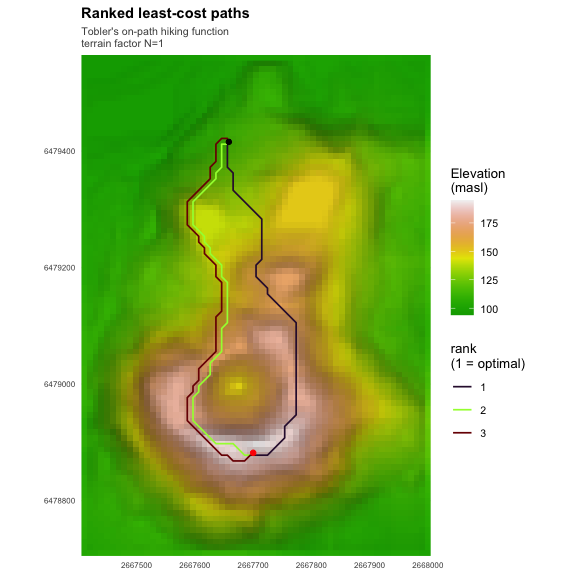

```r
bar2 <- mc_paths(surf8, origin = destin[9, ], destin = destin[2, ])$paths
surf_bar2 <- mc_surface(dtm, funct = "t", move = 8, barrier = bar2)
rk3 <- mc_rank(surf_bar2, origin = destin[1, ], destin = destin[4, ], k = 3)
plot(rk3)
```

## Task 22. Can I visualise the length and cost of each ranked path?

Yes, directly: `plot(rk, type = "chart")` draws the bubble plot, length against rank with bubble size proportional to cost, the equivalent of 2.x’s `add.chart`. No data assembly is needed.

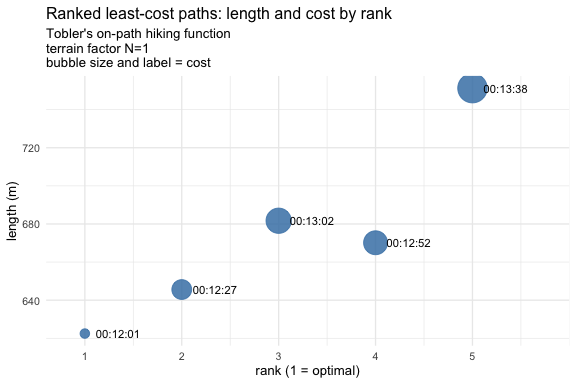

```r
rk_h <- mc_rank(surf8, origin = destin[1, ], destin = destin[4, ],
                k = 5, time = "m")
plot(rk_h, type = "chart")
```

## Saving, exporting, and the cost-function catalogue

```r
# the 26 cost functions, with families, units, and parameter usage
mc_cost_functions()

# persist a result across sessions (use mc_save, NOT saveRDS: SpatRasters
# hold external pointers)
mc_save(acc, "acc.rds")
acc <- mc_load("acc.rds")

# export to GIS formats (GeoTIFF + GeoPackage)
mc_export(lcp, dir = "outputs")
# a surface built with a terrain raster also writes the terrain factors
# actually used (terrain_N_t.tif)
mc_export(surf_T, dir = "outputs")
```

## Reference

Alberti, G. (2019). *movecost: An R package for calculating accumulated slope-dependent anisotropic cost-surfaces and least-cost paths.* SoftwareX, 10, 100331. doi:10.1016/j.softx.2019.100331

Mitchell, A. (2012). *The ESRI Guide to GIS Analysis. Vol. 3.* Esri Press.